# LIMS RQ-PCR Data Analysis

### 2.6.3 IGH vs IGL

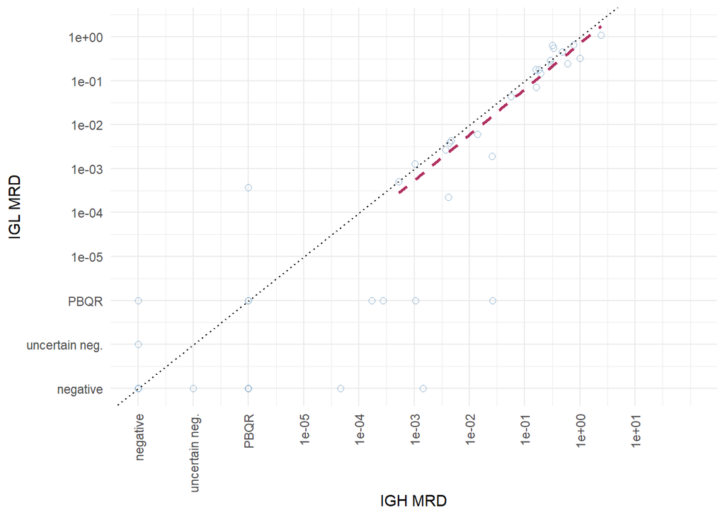

Trend curve calculated only for samples with both MRD values positive quantifiable.

### 2.6.4 IGH vs TRA

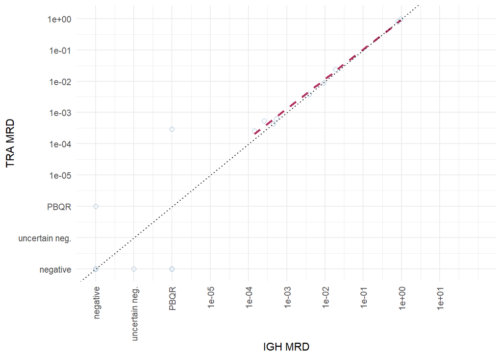

Trend curve calculated only for samples with both MRD values positive quantifiable.

### 2.6.5 IGH vs TRB

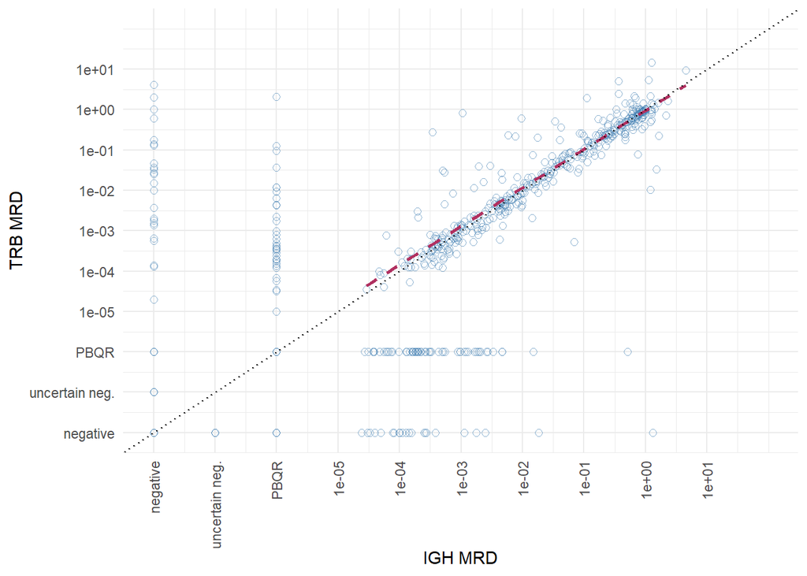

Trend curve calculated only for samples with both MRD values positive quantifiable.

### 2.6.6 IGH vs TRG

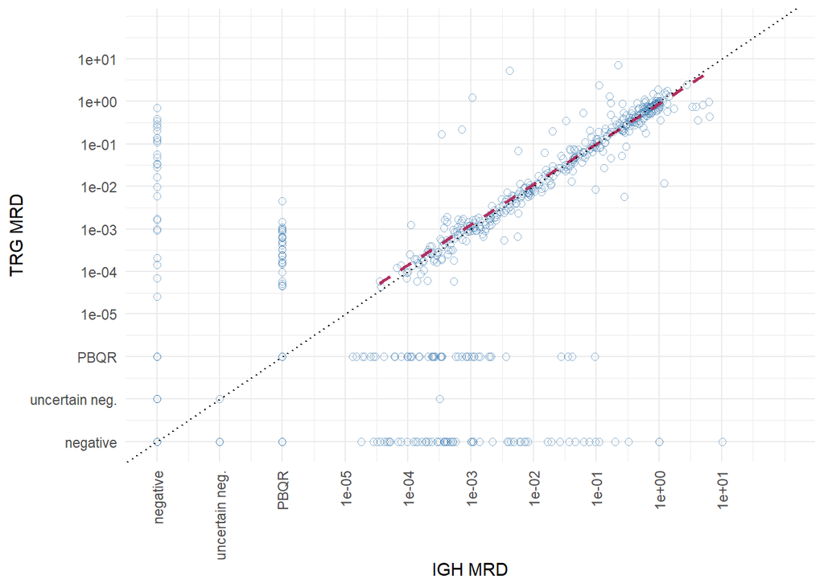

Trend curve calculated only for samples with both MRD values positive quantifiable.

### 2.6.7 IGH vs TRD

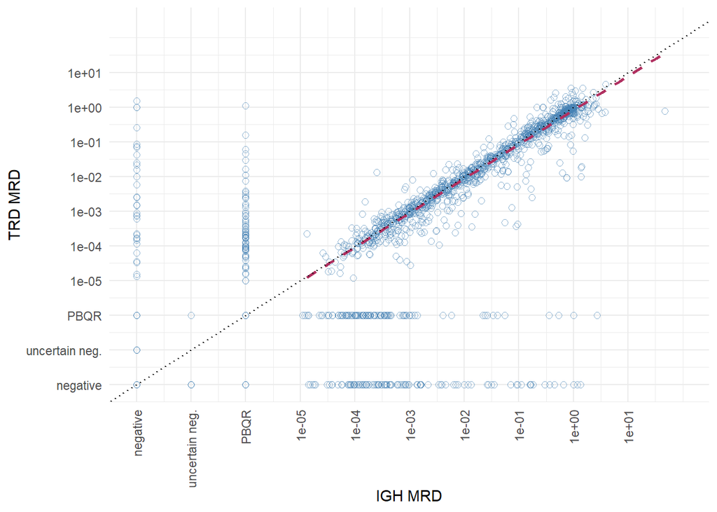

Trend curve calculated only for samples with both MRD values positive quantifiable.

### 2.6.8 IGK vs IGL

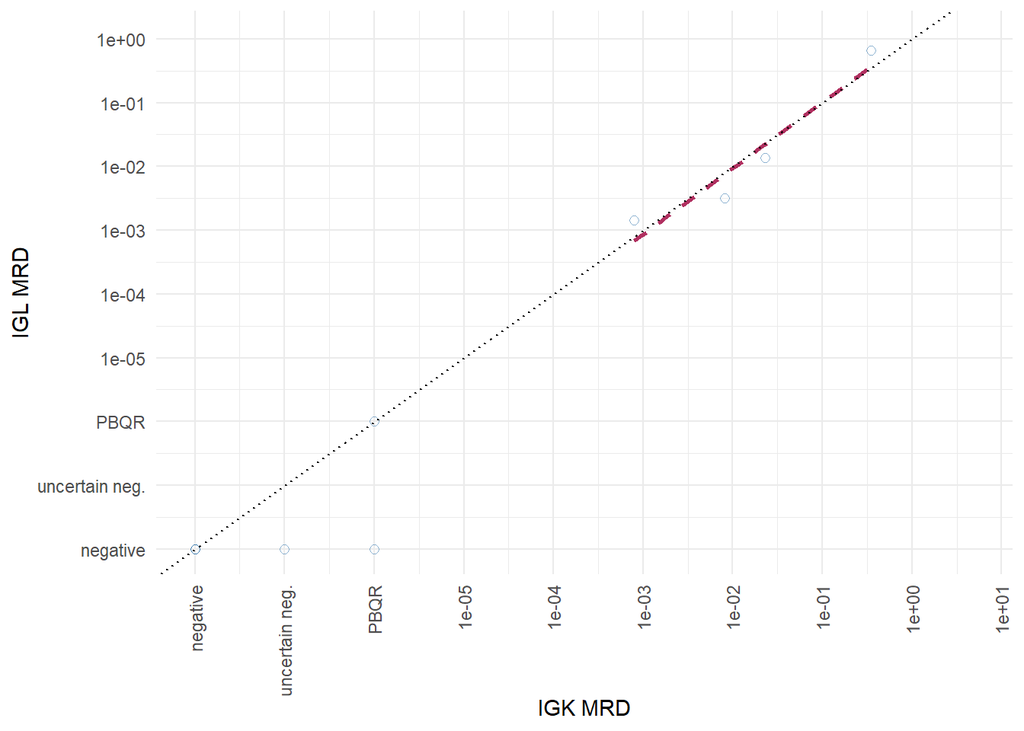

Trend curve calculated only for samples with both MRD values positive quantifiable.

### 2.6.9 IGK vs TRA

[figure not shown]

Trend curve calculated only for samples with both MRD values positive quantifiable.

### 2.6.10 IGK vs TRB

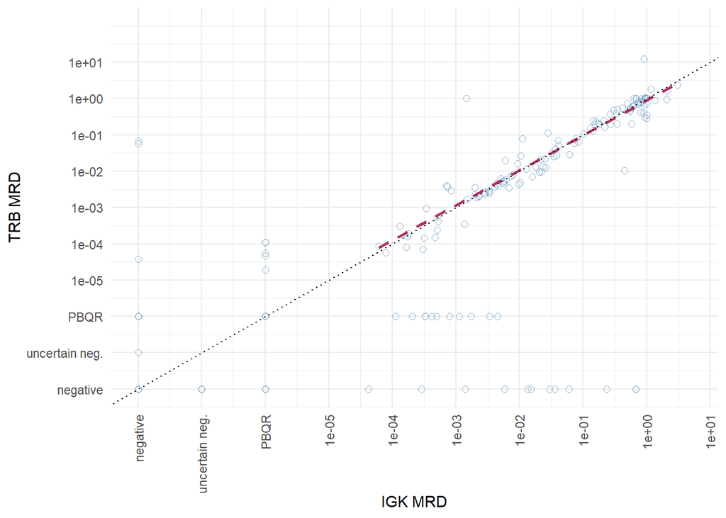

Trend curve calculated only for samples with both MRD values positive quantifiable.

### 2.6.11 IGK vs TRG

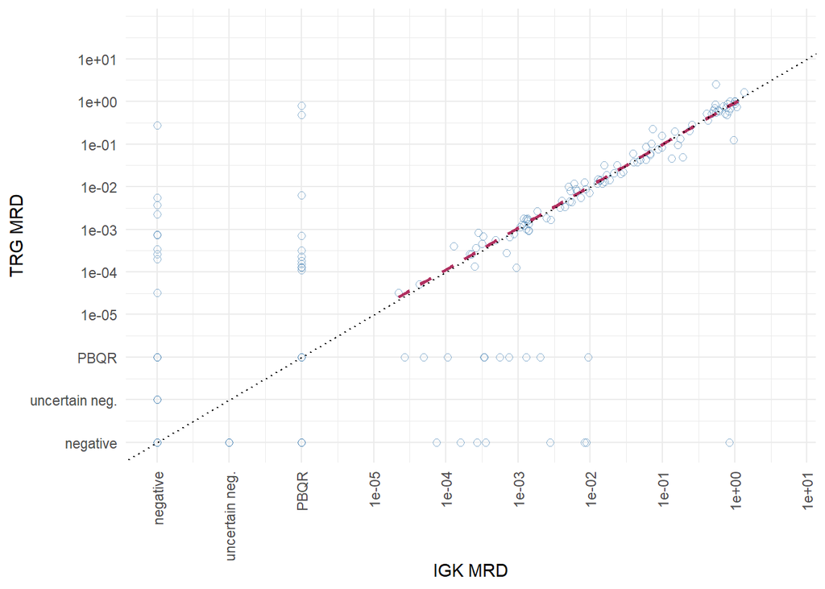

Trend curve calculated only for samples with both MRD values positive quantifiable.

### 2.6.12 IGK vs TRD

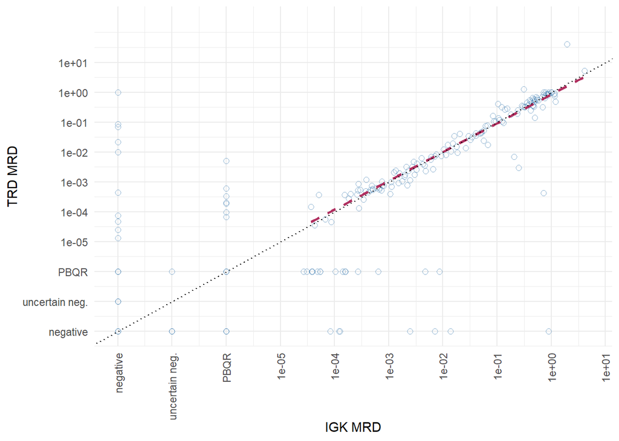

Trend curve calculated only for samples with both MRD values positive quantifiable.

### 2.6.13 IGL vs TRA

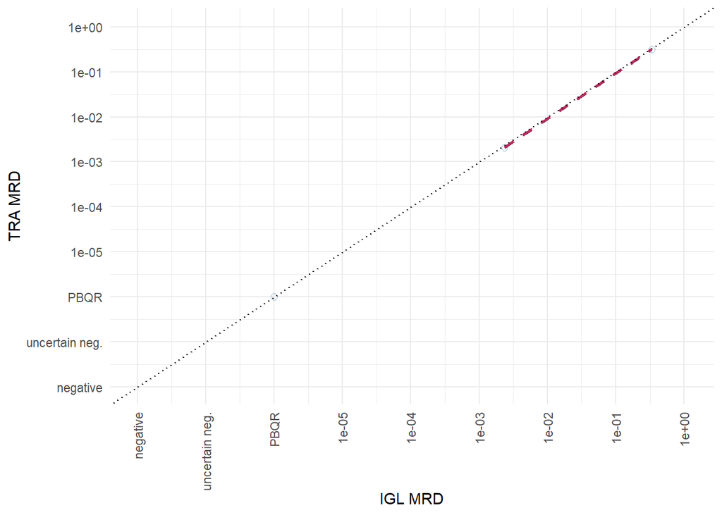

Trend curve calculated only for samples with both MRD values positive quantifiable.

### 2.6.14 IGL vs TRB

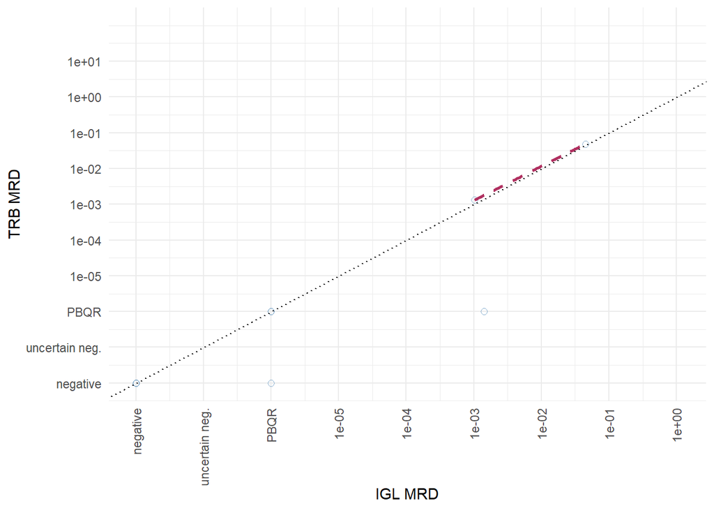

Trend curve calculated only for samples with both MRD values positive quantifiable.

### 2.6.15 IGL vs TRG

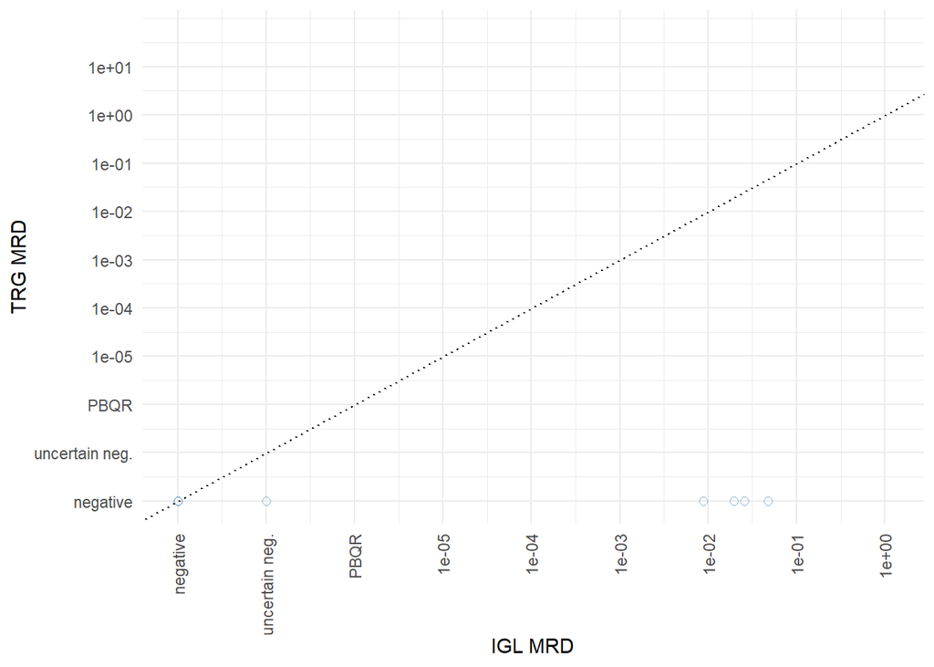

Trend curve calculated only for samples with both MRD values positive quantifiable.

### 2.6.16 IGL vs TRD

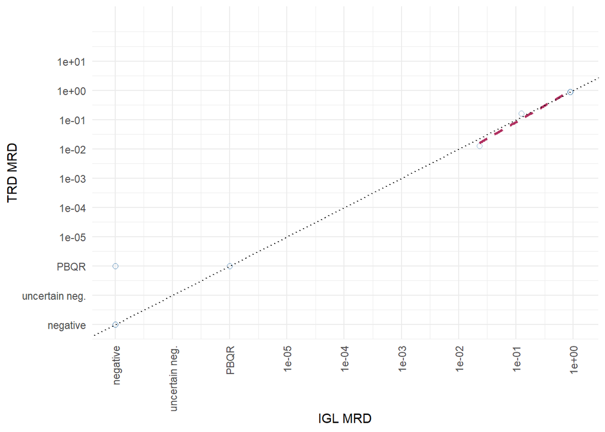

Trend curve calculated only for samples with both MRD values positive quantifiable.

### 2.6.17 TRA vs TRB

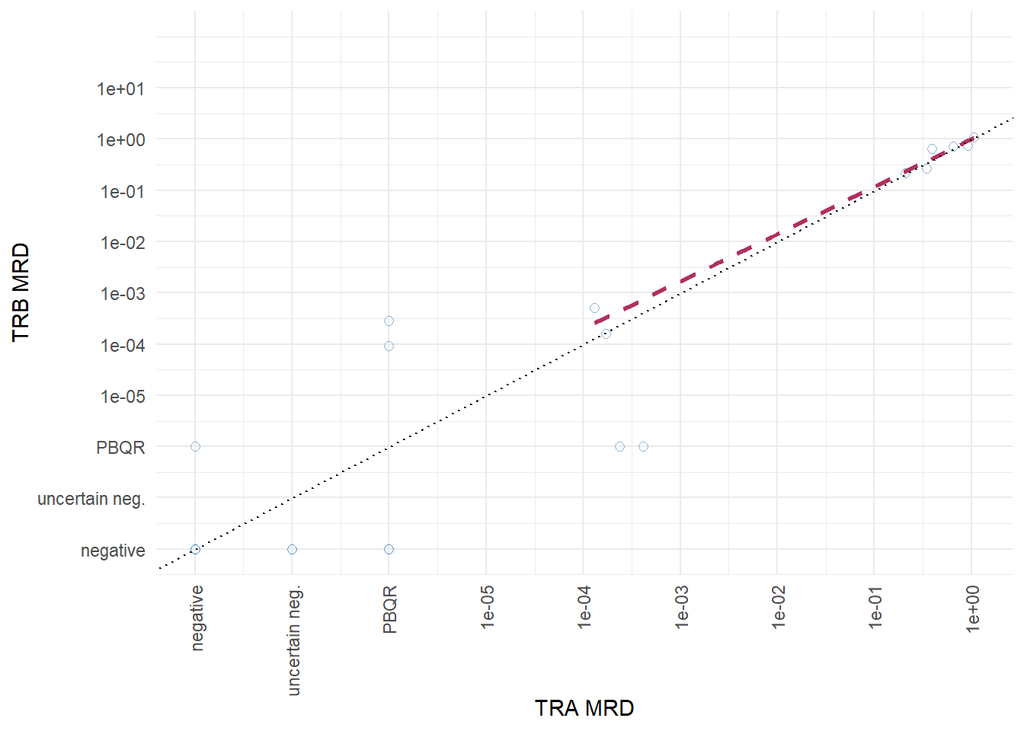

Trend curve calculated only for samples with both MRD values positive quantifiable.

### 2.6.18 TRA vs TRG

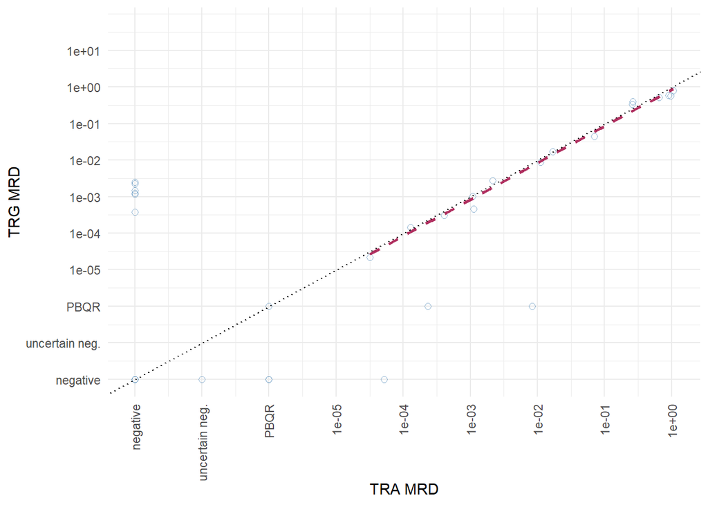

Trend curve calculated only for samples with both MRD values positive quantifiable.

### 2.6.19 TRA vs TRD

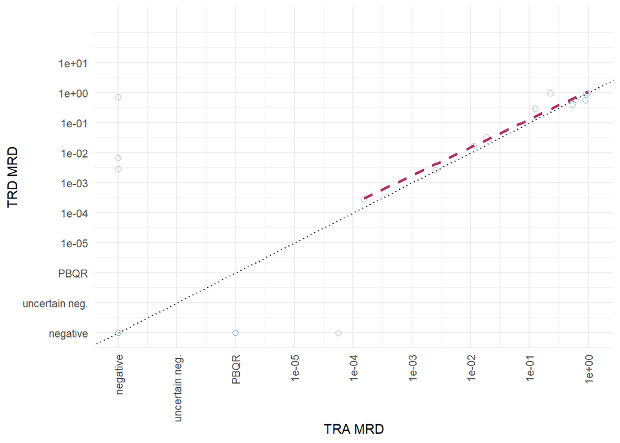

Trend curve calculated only for samples with both MRD values positive quantifiable.

### 2.6.20 TRB vs TRG

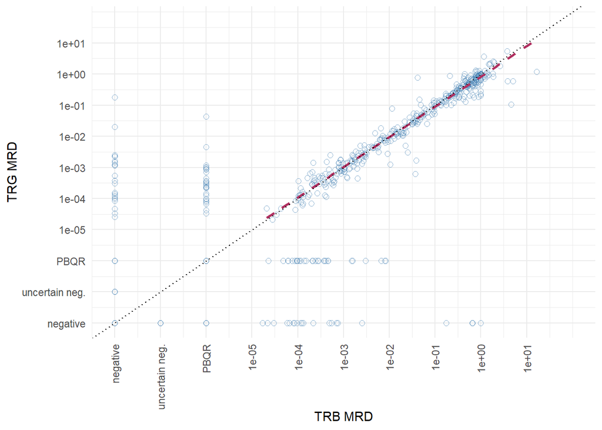

Trend curve calculated only for samples with both MRD values positive quantifiable.

### 2.6.21 TRB vs TRD

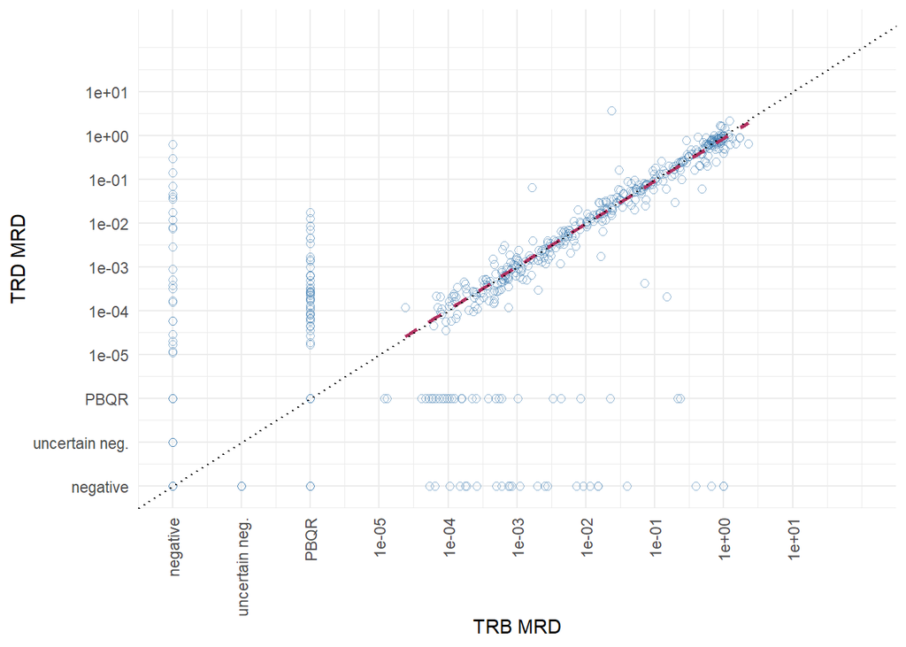

Trend curve calculated only for samples with both MRD values positive quantifiable.

### 2.6.22 TRG vs TRD

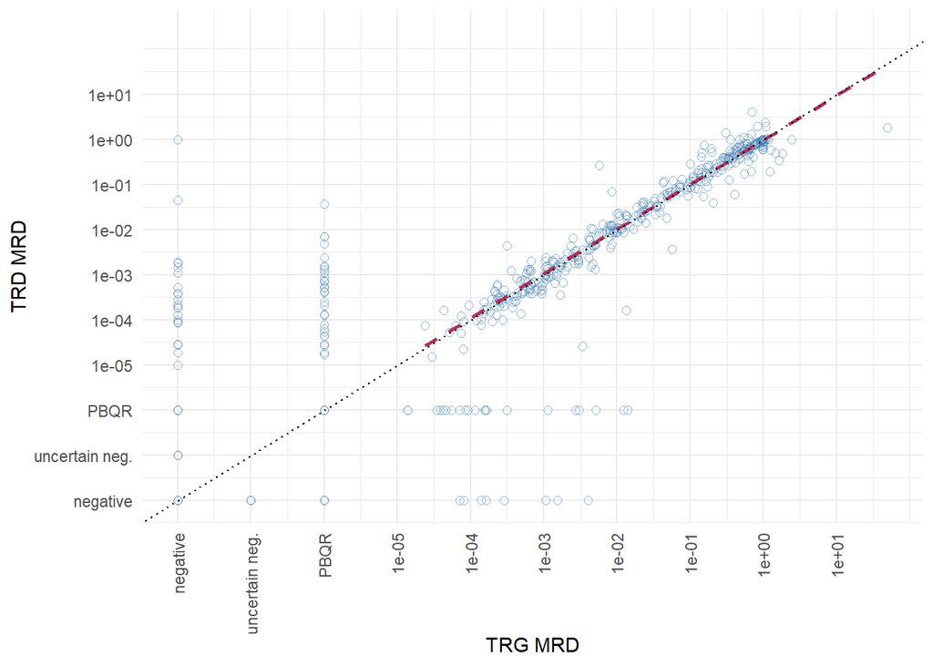

## 2.7 Qualitative Concordance of MRD Assessments

> Same *dna-nr*, different *assays*.  
> If more MRD values for a particular *dna-nr*/*assay* combination available, only the highest one was kept.

**Click to show **Shortcut explanations**

| Shortcut | Meaning |
| --- | --- |
| **NEG** | Negative |
| **POS** | Positive |
| **PBQR** | Positive Below Quantitative Range |
| **UNEG** | Uncertain Negative |

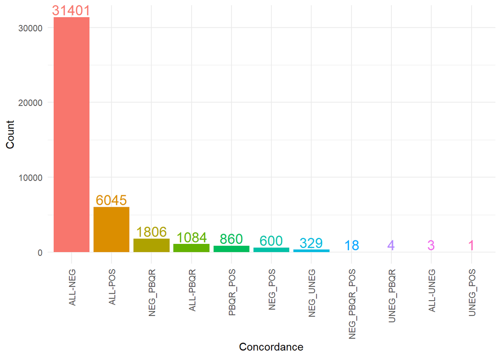

| concordance | Count | pct |
| --- | --- | --- |
| ALL-NEG | 31401 | 74.5 |
| ALL-POS | 6045 | 14.3 |
| NEG_PBQR | 1806 | 4.3 |
| ALL-PBQR | 1084 | 2.6 |
| PBQR_POS | 860 | 2 |
| NEG_POS | 600 | 1.4 |
| NEG_UNEG | 329 | 0.8 |
| NEG_PBQR_POS | 18 | 0 |
| UNEG_PBQR | 4 | 0 |
| ALL-UNEG | 3 | 0 |

[output cut: 1 more lines]

**Click to show **MRD status combinations in each concordance group**

| MRD | Count | pct | concordance |
| --- | --- | --- | --- |
| NEG_NEG | 31240 | 57.1 | ALL-NEG |
| NEG_NEG_NEG | 145 | 0.3 | ALL-NEG |
| NEG_NEG_NEG_NEG | 16 | 0 | ALL-NEG |
| PBQR_PBQR | 1079 | 2 | ALL-PBQR |
| PBQR_PBQR_PBQR | 4 | 0 | ALL-PBQR |
| PBQR_PBQR_PBQR_PBQR | 1 | 0 | ALL-PBQR |
| POS_POS | 5961 | 10.9 | ALL-POS |
| POS_POS_POS | 78 | 0.1 | ALL-POS |
| POS_POS_POS_POS | 6 | 0 | ALL-POS |
| UNEG_UNEG | 3 | 0 | ALL-UNEG |

[output cut: 20 more lines]